# Notebook 23 – Solutions

## Getting Started

Before running this notebook, select “Session > Restart R and Clear Output” in the menu above to start a new R session. This will clear any old data sets and give us a blank slate to start with.

## Keylogs

### Getting Started

```r
kl <- read_csv(
  "data/keylogs-1636337989526.csv",
  col_types = "dcccllllldd",
  na = character()
  ) %>%
  mutate(key = if_else(key_code == "Space", " ", key)) %>%
  mutate(key = if_else(key_code == "Enter", "\n", key)) %>%
  filter(type %in% c("up", "down")) %>%
  mutate(action = if_else(stri_length(key) == 1L, "input", "special")) %>%
  select(time, type, key, key_code, action)
kl
```

```
## # A tibble: 1,560 × 5
##     time type  key     key_code  action
##    <dbl> <chr> <chr>   <chr>     <chr>
##  1  6251 down  "Shift" ShiftLeft special
##  2  6342 down  "F"     KeyF      input
##  3  6415 up    "Shift" ShiftLeft special
##  4  6455 up    "f"     KeyF      input
##  5  6599 down  "a"     KeyQ      input
##  6  6708 down  "r"     KeyR      input
##  7  6767 up    "a"     KeyQ      input
##  8  6812 down  " "     Space     input
##  9  6883 up    "r"     KeyR      input
## 10  6920 up    " "     Space     input
## # … with 1,550 more rows
```

If we look at just the “down” rows that “input” text, the key values should more or less spell out all of the text. There will be a few rough edges if you clicked around or had to use the backspace (but not a problem, I did too!).

```r
kl %>%
  filter(type == "down") %>%
  filter(action == "input") %>%
  summarize(key = paste(key, collapse = "")) %>%
  magrittr::use_series(key) %>%
  cat()
```

```
## Far out in the uncharted backwaters of the unfashionable end of the wester n spiral arm of the Galaxy lierss a small unregarded yellow sun.
##
## Orbiting this at a  distance of roughly ninte-ty-two lmillions miles is an utterly insignificant little blue green planet whose ape-descended life forms are so amazingly primitive that they still wthinthink digital watches are a pretty neat idea.
##
## This planet has, or rather had, a problem, which was this: most of the people on it were unhapy for pretty much mall of the time. Many solutions were suggested for this problem, but most of these were largely concerned with the movements of small green pieces of paper, wichich is odd because on t…
```

The last two lines make use of two functions we have not seen so far, but the general code should be understandable.

### Getting Started

Now for you to do a bit of work using the window functions we saw in the notes. We will start just looking at the records of when keys were pressed down. In the code below, filter the data to include only the times that keys were pressed down, create a variable named `tdiff` that gives the time between the successive keys, and computes the median differences between these differences. You will have to use the option `na.rm = TRUE` because there will be a missing value at the end (or beginning) of the data. This value is in milliseconds.

```r
kl %>%
  filter(type == "down") %>%
  mutate(tdiff = time - lag(time, n = 1)) %>%
  summarize(med = median(tdiff, na.rm = TRUE))
```

```
## # A tibble: 1 × 1
##     med
##   <dbl>
## 1   109
```

Let us show the distribution of the differences between successive down buttons. Recreate the column `tdiff`, filter to have only differences of no more than 400ms, and create a plot of the time differences using `geom_histogram`. Take a moment to look at the distribution.

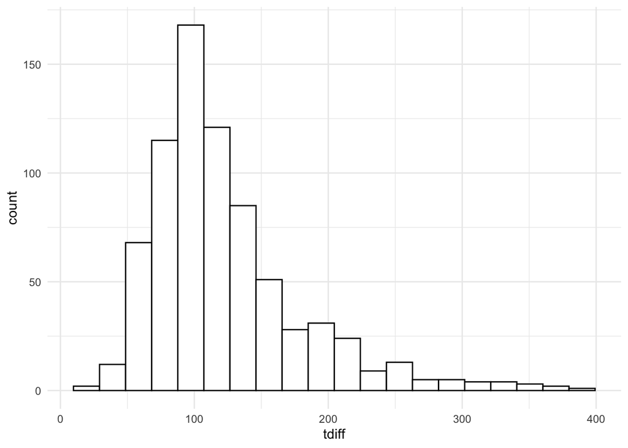

```r
kl %>%
  filter(type == "down") %>%
  mutate(tdiff = time - lag(time, n = 1)) %>%
  filter(tdiff < 400) %>%
  ggplot(aes(tdiff)) +
    geom_histogram(bins = 20, color = "black", fill = "white")
```

Finally, let’s combine the median difference between down actions based on the value of the `key` variable. Do this below, arranging the results in descending order base on the median. Consider adding a count column as well.

```r
kl %>%
  filter(type == "down") %>%
  mutate(tdiff = time - lag(time, n = 1)) %>%
  group_by(key) %>%
  summarize(med = median(tdiff, na.rm = TRUE),n = n()) %>%
  arrange(desc(med))
```

```
## # A tibble: 38 × 3
##    key           med     n
##    <chr>       <dbl> <int>
##  1 ":"          684      1
##  2 "Backspace"  446.    16
##  3 "\n"         298.     4
##  4 "x"          223      1
##  5 "Shift"      215      8
##  6 "z"          212      1
##  7 "d"          191     15
##  8 "w"          185     17
##  9 ","          150      5
## 10 "'"          144      1
## # … with 28 more rows
```

Take note of the keys that have the largest and smallest median values.

### Grouping Keys

We now want to create a data set that has one row for each key that was pressed that contains information about when the key was pressed and when it was released. This can be very tricky if we are not careful, so I will walk you through the process. Here is a step-by-step description of how we will do this:

- group the data by the `key_code` variable
- create a new variable called `time_down` that is equal to the time
- create a new variable called `time_up` that gives the time of the next key
- filter to only include rows where the NEXT type is “up”
- filter to only include rows where the type is “down”
- remove rows with a missing time_up
- ungroup the data
- select the columns time_down, time_up, key, key_code, and action

Apply the steps above in the block below. When you are satisfied, save the results as an object named `keys`.

```r
keys <- kl %>%
  arrange(time) %>%                                  # should already be true
  group_by(key_code) %>%
  mutate(time_down = time) %>%
  mutate(time_up = lead(time, n = 1)) %>%
  filter(lead(type, n = 1) == "up") %>%
  filter(type == "down") %>%
  filter(!is.na(time_up)) %>%                        # just in case
  ungroup() %>%
  select(time_down, time_up, key, key_code, action)

keys
```

```
## # A tibble: 780 × 5
##    time_down time_up key     key_code  action
##        <dbl>   <dbl> <chr>   <chr>     <chr>
##  1      6251    6415 "Shift" ShiftLeft special
##  2      6342    6455 "F"     KeyF      input
##  3      6599    6767 "a"     KeyQ      input
##  4      6708    6883 "r"     KeyR      input
##  5      6812    6920 " "     Space     input
##  6      6999    7110 "o"     KeyO      input
##  7      7070    7158 "u"     KeyU      input
##  8      7118    7246 "t"     KeyT      input
##  9      7206    7322 " "     Space     input
## 10      7283    7395 "i"     KeyI      input
## # … with 770 more rows
```

Using the data you just created, compute the median duration between the time a key was pressed and released.

```r
keys %>%
  mutate(duration = time_up - time_down) %>%
  summarize(med = median(duration))
```

```
## # A tibble: 1 × 1
##     med
##   <dbl>
## 1   100
```

Now, compute the median duration between the time a key was pressed and released grouped on the value of `key_code`. Arrange the results in descending order of the median.

```r
keys %>%
  mutate(duration = time_up - time_down) %>%
  group_by(key_code) %>%
  summarize(med = median(duration)) %>%
  arrange(desc(med))
```

```
## # A tibble: 33 × 2
##    key_code    med
##    <chr>     <dbl>
##  1 ShiftLeft  242.
##  2 Period     117
##  3 KeyX       115
##  4 Digit4     113
##  5 KeyR       113
##  6 Space      113
##  7 KeyS       108
##  8 KeyE       107
##  9 KeyB       104
## 10 KeyL       103
## # … with 23 more rows
```

```r
keys %>%
  mutate(duration = lead(time_down) - time_up) %>%
  group_by(key_code) %>%
  filter(!is.na(duration)) %>%
  summarize(med = median(duration)) %>%
  arrange(med)
```

```
## # A tibble: 33 × 2
##    key_code     med
##    <chr>      <dbl>
##  1 ShiftLeft -127
##  2 KeyU       -15
##  3 KeyB       -12
##  4 KeyE       -12
##  5 KeyR       -12
##  6 KeyI        -7
##  7 KeyO        -4.5
##  8 KeyS        -2
##  9 KeyH        -1.5
## 10 KeyX         0
## # … with 23 more rows
```

Do notice anything interesting? Note that these can be negative. Try to understand why this is the case.

### Words

As a final task, let’s group the data together in order to create a structure around the individual words. To do this we will end up using a window function. Before we do the whole thing, let’s take a baby step. Below, take the `keys` data and add a variable called `whitespace` that is a logical value equal to whether the key is either a space or a newline. Then, add a column called `word_id` that is equal to `cumsum(whitespace)`. Look at the results and understand what it is doing.

```r
keys %>%
  mutate(whitespace = (key %in% c(" ", "\n"))) %>%
  mutate(word_id = cumsum(whitespace))
```

```
## # A tibble: 780 × 7
##    time_down time_up key     key_code  action  whitespace word_id
##        <dbl>   <dbl> <chr>   <chr>     <chr>   <lgl>        <int>
##  1      6251    6415 "Shift" ShiftLeft special FALSE            0
##  2      6342    6455 "F"     KeyF      input   FALSE            0
##  3      6599    6767 "a"     KeyQ      input   FALSE            0
##  4      6708    6883 "r"     KeyR      input   FALSE            0
##  5      6812    6920 " "     Space     input   TRUE             1
##  6      6999    7110 "o"     KeyO      input   FALSE            1
##  7      7070    7158 "u"     KeyU      input   FALSE            1
##  8      7118    7246 "t"     KeyT      input   FALSE            1
##  9      7206    7322 " "     Space     input   TRUE             2
## 10      7283    7395 "i"     KeyI      input   FALSE            2
## # … with 770 more rows
```

Below, create a data set called `words` that has the variable `word_id` and removes the rows containing whitespae and only includes the action “input”.

```r
words <- keys %>%
  mutate(whitespace = (key %in% c(" ", "\n"))) %>%
  mutate(word_id = cumsum(whitespace)) %>%
  filter(!whitespace) %>%
  filter(action == "input")
```

Using the words data, group by the `word_id` variable and compute (within a summarize verb) three summaries: the minimum value of the time_down, the maximum value of the time_up, and the value of the word as the pasted together keys.

```r
words %>%
  group_by(word_id) %>%
  summarize(
    time_down = min(time_down),
    time_up = max(time_up),
    word = paste0(key, collapse = "")
  )
```

```
## # A tibble: 129 × 4
##    word_id time_down time_up word
##      <int>     <dbl>   <dbl> <chr>
##  1       0      6342    6883 Far
##  2       1      6999    7246 out
##  3       2      7283    7455 in
##  4       3      7474    7749 the
##  5       4      7807    9082 uncharted
##  6       5      9745   11146 backwaters
##  7       6     11253   11374 of
##  8       7     11458   11721 the
##  9       8     11717   13289 unfashionable
## 10       9     13384   13704 end
## # … with 119 more rows
```

Starting with what you did above, compute the time it took you to type each word. Arrange the data from the longest time to the shortest time.

```r
words %>%
  group_by(word_id) %>%
  summarize(
    time_down = min(time_down),
    time_up = max(time_up),
    word = paste0(key, collapse = "")
  ) %>%
  mutate(tdiff = time_up - time_down) %>%
  arrange(desc(tdiff))
```

```
## # A tibble: 129 × 5
##    word_id time_down time_up word          tdiff
##      <int>     <dbl>   <dbl> <chr>         <dbl>
##  1      34     34118   37207 ninte-ty-two   3089
##  2      56     56173   58939 wthinthink     2766
##  3      46     47412   49635 ape-descended  2223
##  4      87     86724   88863 mall           2139
##  5      40     41183   43121 insignificant  1938
##  6      66     66132   67911 planet         1779
##  7     114    105735  107460 wichich        1725
##  8      35     37354   39028 lmillions      1674
##  9       8     11717   13289 unfashionable  1572
## 10      22     23350   24835 unregarded     1485
## # … with 119 more rows
```

Finally, if you have time, filter the words to just the first 20 ids. Then, create a geom_segment plot showing when each word was typed. Try to add some labels.

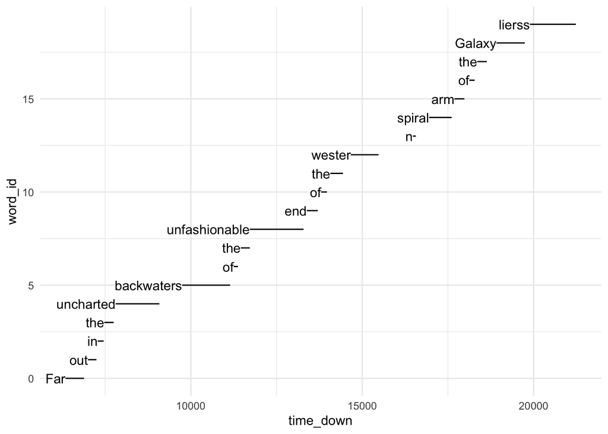

```r
words %>%
  filter(word_id < 20) %>%
  group_by(word_id) %>%
  summarize(
    time_down = min(time_down),
    time_up = max(time_up),
    word = paste0(key, collapse = "")
  ) %>%
  ggplot(aes(x = time_down, y = word_id)) +
    geom_segment(aes(xend = time_up, yend = word_id)) +
    geom_text(aes(label = word), hjust = "right")
```

Notice that there are some errors because of mis-typed words (we would need more complex logic to deal with those).